# Math 3B: AI Tutor Usage and Student Learning Outcomes

Xiao Long

2026-01-30

```r
library(tidyverse)
library(ggplot2)
library(dplyr)
library(readxl)
library(broom)
```

## Overview

This notebook analyzes student-level learning outcomes from a live AI-powered math tutoring platform (Vocareum) used in a UC-affiliated Math 3B (Calculus) course during Fall 2025. Each row corresponds to one student.

**Research questions:**

1. Does AI tutor usage predict learning gains?
2. Does practice volume predict learning gains?
3. What is the probability that a student improves at all, and what drives it?

## Data Overview

```r
df_raw <- read_excel("../data/FA25 Math 3B Data - Full Quarter.xlsx", sheet = 1)
df_raw %>% glimpse()
```

```
## Rows: 280
## Columns: 13
## $ USERID                                   <dbl> 4437500, 4437521, 3972077, 44…
## $ `Pretest Grade`                          <chr> "0.01923076923", "0.038461538…
## $ `Midterm I Grade`                        <chr> "#VALUE!", "0.2", "0.56923076…
## $ `Midterm II Grade`                       <chr> "0.02702702703", "0.175675675…
## $ `Final Exam Grade`                       <chr> "0", "0.1858974359", "0.39102…
## $ `Final Grade in Course`                  <chr> "F", "F", "F", "A-", "F", "F"…
## $ `Delta (pre to final)`                   <chr> "-0.01923076923", "0.14743589…
## $ `#of tutor requests`                     <chr> "0", "193", "7", "64", "24", …
## $ `# of questions correct`                 <dbl> 114, 131, 66, 219, 176, 170, …
## $ `# of questions incorrect`               <dbl> 130, 166, 58, 198, 84, 141, 2…
## $ `Total Questions Seen`                   <dbl> 129, 185, 100, 251, 181, 180,…
## $ Accuracy                                 <chr> "0.4672131148", "0.4410774411…
## $ `Number of Questions Right at First Try` <lgl> NA, NA, NA, NA, NA, NA, NA, N…
```

## Data Cleaning

Raw data from the platform contains Excel error tokens (`#VALUE!`, `#N/A`, etc.) that must be handled before analysis.

```r
to_num <- function(x) {
  x <- as.character(x)
  x <- str_trim(x)
  x[x %in% c("#VALUE!", "#N/A", "#DIV/0!", "#ERROR!", "", "NA")] <- NA
  suppressWarnings(as.numeric(x))
}

df <- df_raw %>%
  mutate(
    pretest        = to_num(`Pretest Grade`),
    mid1           = to_num(`Midterm I Grade`),
    mid2           = to_num(`Midterm II Grade`),
    final_exam     = to_num(`Final Exam Grade`),
    tutor_requests = to_num(`#of tutor requests`),
    n_correct      = to_num(`# of questions correct`),
    n_incorrect    = to_num(`# of questions incorrect`),
    total_seen     = to_num(`Total Questions Seen`),
    accuracy       = to_num(`Accuracy`)
  ) %>%
  mutate(
    delta    = final_exam - pretest,
    attempts = n_correct + n_incorrect,
    error_rate = ifelse(attempts > 0, n_incorrect / attempts, NA_real_)
  )
```

## Learning Gain Distribution

```r
df_valid <- df %>%
  filter(!is.na(delta), !is.na(tutor_requests), !is.na(pretest))

nrow(df_valid)
```

```
## [1] 258
```

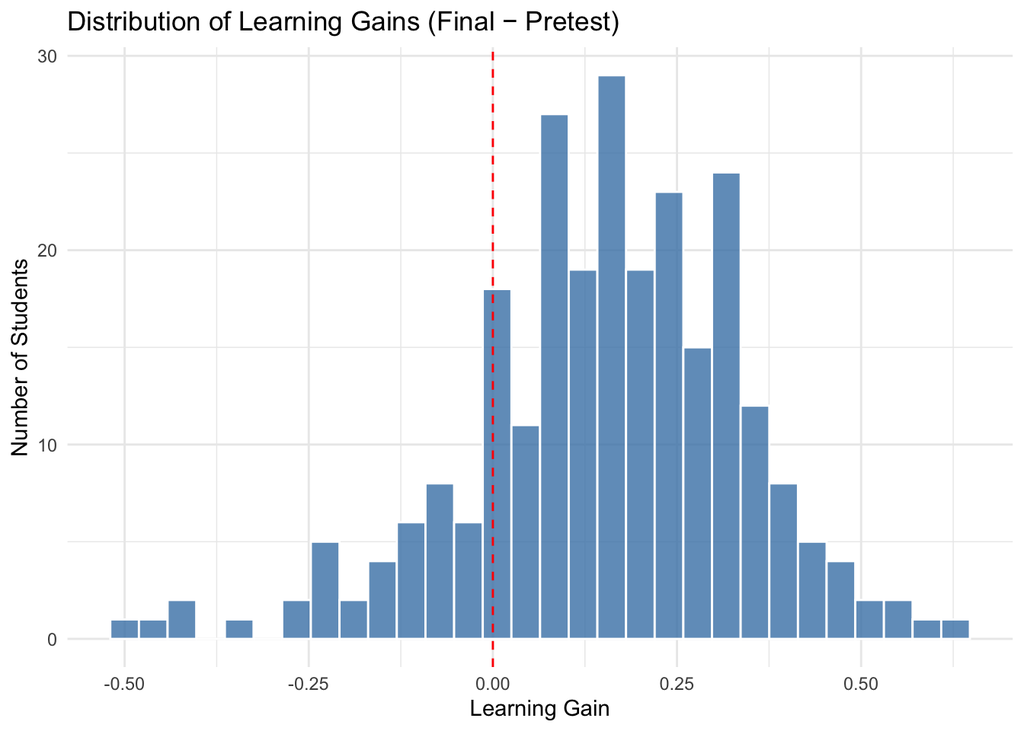

```r
ggplot(df_valid, aes(x = delta)) +
  geom_histogram(bins = 30, fill = "steelblue", alpha = 0.8, color = "white") +
  geom_vline(xintercept = 0, color = "red", linetype = "dashed") +
  labs(
    title = "Distribution of Learning Gains (Final − Pretest)",
    x = "Learning Gain",
    y = "Number of Students"
  ) +
  theme_minimal()
```

Most students show positive learning gains over the quarter. A subset show zero or negative gain, motivating binary outcome analysis later.

## Quantile-Based Student Grouping

To avoid arbitrary cutoffs, students are grouped into Low / Middle / High categories using quartiles of tutor usage and practice volume.

```r
df_a <- df_valid %>%
  mutate(
    tutor_q = ntile(tutor_requests, 4),
    tutor_group = case_when(
      tutor_q == 1 ~ "Low (Q1)",
      tutor_q == 4 ~ "High (Q4)",
      TRUE         ~ "Middle (Q2–Q3)"
    ),
    tutor_group = factor(tutor_group, levels = c("Low (Q1)", "Middle (Q2–Q3)", "High (Q4)"))
  )

df_b <- df %>%
  filter(!is.na(total_seen), !is.na(pretest), !is.na(delta)) %>%
  mutate(
    seen_q = ntile(total_seen, 4),
    effort_group = case_when(
      seen_q == 1 ~ "Low (Q1)",
      seen_q == 4 ~ "High (Q4)",
      TRUE        ~ "Middle (Q2–Q3)"
    ),
    effort_group = factor(effort_group, levels = c("Low (Q1)", "Middle (Q2–Q3)", "High (Q4)"))
  )
```

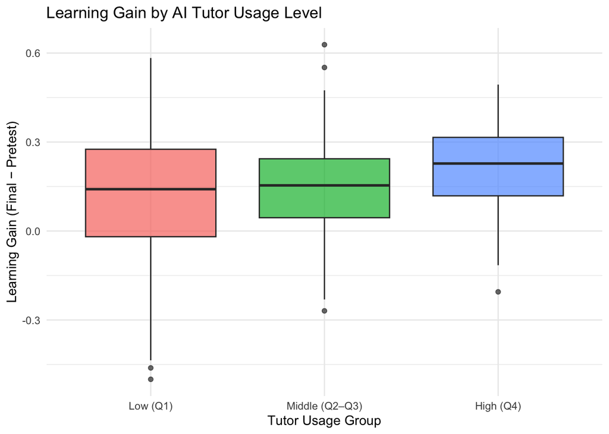

```r
ggplot(df_a, aes(x = tutor_group, y = delta, fill = tutor_group)) +
  geom_boxplot(alpha = 0.7) +
  labs(
    title = "Learning Gain by AI Tutor Usage Level",
    x = "Tutor Usage Group",
    y = "Learning Gain (Final − Pretest)"
  ) +
  theme_minimal() +
  theme(legend.position = "none")
```

Students with higher AI tutor usage tend to show higher median learning gains, though overlap across groups is substantial.

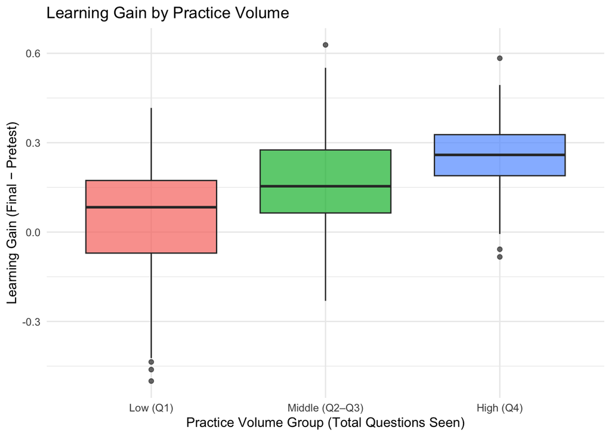

```r
ggplot(df_b, aes(x = effort_group, y = delta, fill = effort_group)) +
  geom_boxplot(alpha = 0.7) +
  labs(
    title = "Learning Gain by Practice Volume",
    x = "Practice Volume Group (Total Questions Seen)",
    y = "Learning Gain (Final − Pretest)"
  ) +
  theme_minimal() +
  theme(legend.position = "none")
```

Students who practiced more (higher total questions seen) show notably larger learning gains compared to lower-practice groups.

## Linear Regression: Predicting Magnitude of Learning Gains

### Model A — AI Tutor Usage

```r
model_a <- lm(delta ~ tutor_requests + pretest, data = df_a)
summary(model_a)
```

```
##
## Call:
## lm(formula = delta ~ tutor_requests + pretest, data = df_a)
##
## Residuals:
##      Min       1Q   Median       3Q      Max
## -0.65137 -0.08328  0.01275  0.11385  0.37561
##
## Coefficients:
##                  Estimate Std. Error t value Pr(>|t|)
## (Intercept)     0.3910131  0.0393583   9.935  < 2e-16 ***
## tutor_requests  0.0002914  0.0001326   2.198   0.0288 *
## pretest        -0.4833704  0.0688771  -7.018 2.03e-11 ***
## ---
## Signif. codes:  0 '***' 0.001 '**' 0.01 '*' 0.05 '.' 0.1 ' ' 1
##
## Residual standard error: 0.1691 on 255 degrees of freedom
## Multiple R-squared:  0.1796, Adjusted R-squared:  0.1732
## F-statistic: 27.91 on 2 and 255 DF,  p-value: 1.093e-11
```

Tutor requests have a small but statistically significant positive association with learning gain (p < 0.05). Pretest score is strongly negative — students who start higher have less room to improve (ceiling effect). Adjusted R² ≈ 0.18.

### Model B — Practice Volume

```r
model_b <- lm(delta ~ total_seen + pretest, data = df_b)
summary(model_b)
```

```
##
## Call:
## lm(formula = delta ~ total_seen + pretest, data = df_b)
##
## Residuals:
##      Min       1Q   Median       3Q      Max
## -0.60090 -0.07746  0.01962  0.08470  0.33860
##
## Coefficients:
##               Estimate Std. Error t value Pr(>|t|)
## (Intercept)  0.0419124  0.0524215   0.800    0.425
## total_seen   0.0017111  0.0001865   9.174  < 2e-16 ***
## pretest     -0.5219757  0.0603002  -8.656 5.62e-16 ***
## ---
## Signif. codes:  0 '***' 0.001 '**' 0.01 '*' 0.05 '.' 0.1 ' ' 1
##
## Residual standard error: 0.148 on 255 degrees of freedom
## Multiple R-squared:  0.3715, Adjusted R-squared:  0.3665
## F-statistic: 75.36 on 2 and 255 DF,  p-value: < 2.2e-16
```

Practice volume (total questions seen) has a large and highly significant positive effect (p < 0.001). This model explains substantially more variance than Model A (Adjusted R² ≈ 0.37), suggesting overall practice intensity matters more than AI tutor usage alone.

### Visualization

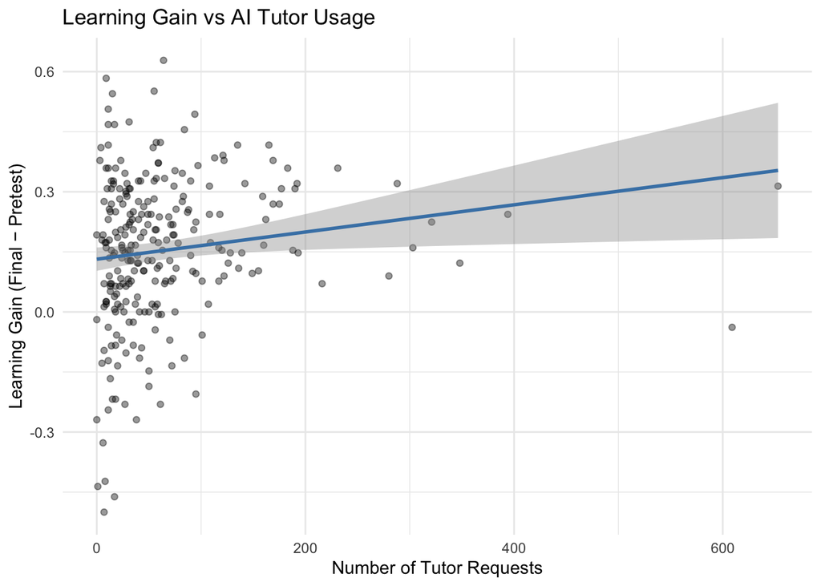

```r
ggplot(df_a, aes(x = tutor_requests, y = delta)) +
  geom_point(alpha = 0.4) +
  geom_smooth(method = "lm", se = TRUE, color = "steelblue") +
  labs(
    title = "Learning Gain vs AI Tutor Usage",
    x = "Number of Tutor Requests",
    y = "Learning Gain (Final − Pretest)"
  ) +
  theme_minimal()
```

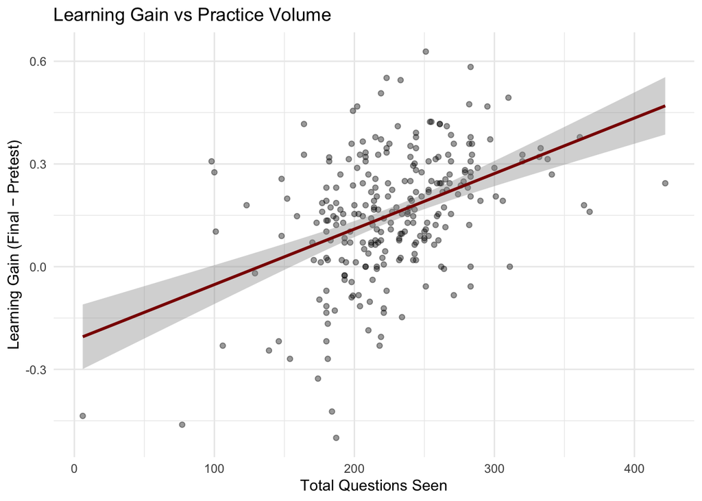

```r
ggplot(df_b, aes(x = total_seen, y = delta)) +
  geom_point(alpha = 0.4) +
  geom_smooth(method = "lm", se = TRUE, color = "darkred") +
  labs(
    title = "Learning Gain vs Practice Volume",
    x = "Total Questions Seen",
    y = "Learning Gain (Final − Pretest)"
  ) +
  theme_minimal()
```

## Logistic Regression: Probability of Improvement

Beyond the magnitude of gains, we model whether students improve at all (binary outcome).

```r
df_logit <- df_valid %>%
  mutate(improved = ifelse(delta > 0, 1, 0))

table(df_logit$improved)
```

```
##
##   0   1
##  46 212
```

```r
logit_model <- glm(
  improved ~ accuracy + tutor_requests + pretest,
  data   = df_logit,
  family = binomial
)
summary(logit_model)
```

```
##
## Call:
## glm(formula = improved ~ accuracy + tutor_requests + pretest,
##     family = binomial, data = df_logit)
##
## Coefficients:
##                 Estimate Std. Error z value Pr(>|z|)
## (Intercept)     2.164638   1.259442   1.719  0.08566 .
## accuracy        2.036356   1.893430   1.075  0.28216
## tutor_requests  0.005398   0.003524   1.532  0.12560
## pretest        -3.807682   1.219238  -3.123  0.00179 **
## ---
## Signif. codes:  0 '***' 0.001 '**' 0.01 '*' 0.05 '.' 0.1 ' ' 1
##
## (Dispersion parameter for binomial family taken to be 1)
##
##     Null deviance: 241.90  on 257  degrees of freedom
## Residual deviance: 226.73  on 254  degrees of freedom
## AIC: 234.73
##
## Number of Fisher Scoring iterations: 5
```

Pretest grade is a strong and significant negative predictor of improvement probability — students who start higher are less likely to show any measured gain (ceiling effect). Tutor accuracy and request frequency show positive associations but do not consistently reach significance, suggesting baseline performance dominates.

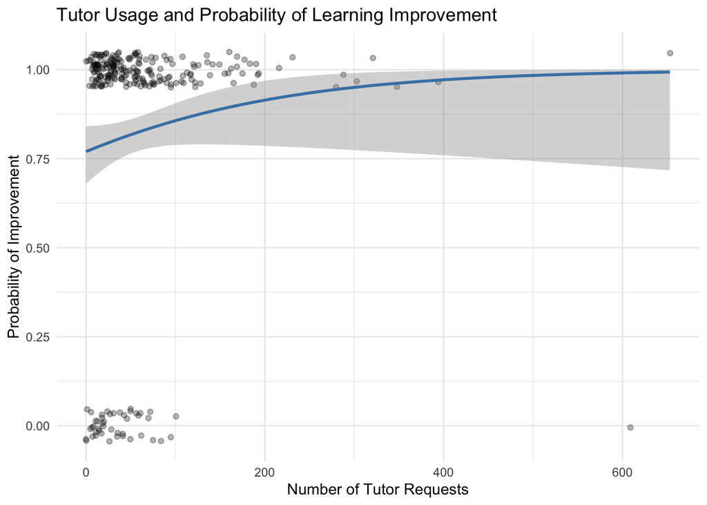

```r
ggplot(df_logit, aes(x = tutor_requests, y = improved)) +
  geom_jitter(height = 0.05, alpha = 0.3) +
  geom_smooth(method = "glm", method.args = list(family = "binomial"), color = "steelblue") +
  labs(
    title = "Tutor Usage and Probability of Learning Improvement",
    x = "Number of Tutor Requests",
    y = "Probability of Improvement"
  ) +
  theme_minimal()
```

## Binary Outcome: Tutor Usage by Improvement Group

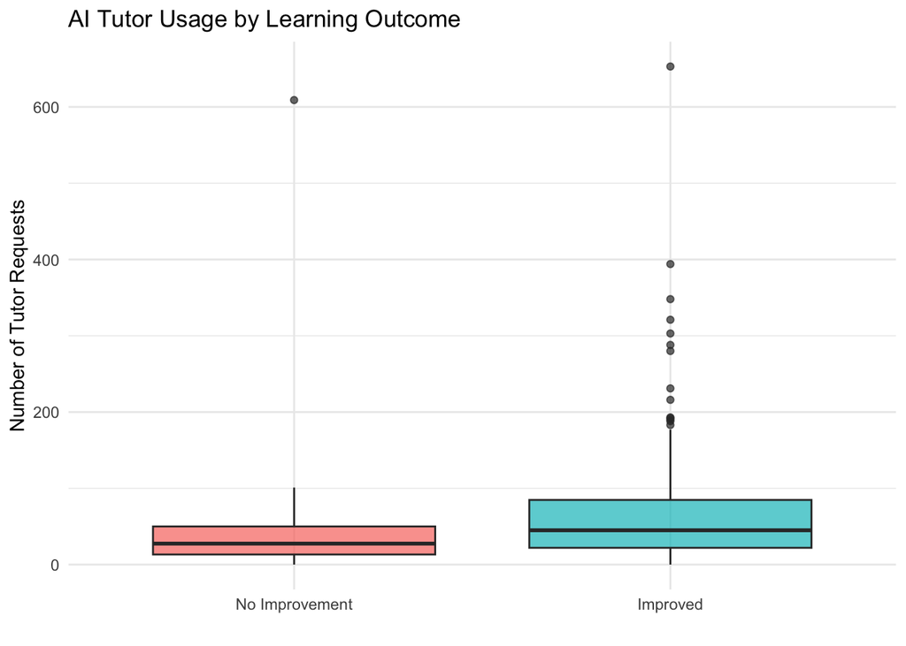

```r
df_logit <- df_logit %>%
  mutate(
    improved_label = factor(improved, levels = c(0, 1),
                            labels = c("No Improvement", "Improved"))
  )

ggplot(df_logit, aes(x = improved_label, y = tutor_requests, fill = improved_label)) +
  geom_boxplot(alpha = 0.7) +
  labs(
    title = "AI Tutor Usage by Learning Outcome",
    x = "",
    y = "Number of Tutor Requests"
  ) +
  theme_minimal() +
  theme(legend.position = "none")
```